# Counting Reads

Aditi Gopalan

05/03/2022

## Part 1 - Running featureCounts

I first checked to see what parameters were in the function and what their respective default values were

```
spack load subread
featureCounts default
```

Here are two of the parameters

`-t :` This specifies the feature type. Only the rows which match with the feature type in the GTF file are included for counting. The default type is ‘exon’

`-g:` This specifies the attribute type used to group features into metafeatures. In this case, exons into genes. The default value is ‘gene_id’

`-T:` This specifies the number of threads. I used 5 for speed.

I ran the following command taking the reading annotations file and BAM file as input, the result will be stored in counts.txt

```
featureCounts -T 5 -a /home/frd2007/ANGSD_2019/alignment/refGenome_S_cerevisiae/sacCer3.gtf -t exon -g gene_id -o counts.txt /home/frd2007/ANGSD_2019/alignment/*.bam
```

```
|                                                                            ||
||                         Read assignment finished.                          ||
||                                                                            ||
|| Summary of counting results can be found in file "counts.txt.summary"      ||
||                                                                            ||
\\===================== http://subread.sourceforge.net/ ======================//
```

## Part 2 - Reading the summary files

I copied the results on to my local computer using scp

```
scp adg4001@aphrodite.med.cornell.edu:/home/adg4001/featurecounts/counts.txt .
```

Reading the files into R and renaming them for convenience

```r
library(ggplot2)
theme_set(theme_bw(base_size = 16)) # for making plots
library(magrittr) # for "pipe"-like coding in R (R < v.4.1)

folder <- "C:/Users/aditi/Desktop/angsd/angsd-practice" # download count table!
## reading in featureCounts output
readcounts <- paste0(folder, "/counts.txt.summary") %>%
read.table(., header=TRUE)
str(readcounts)
```

```
## 'data.frame':    12 obs. of  11 variables:
##  $ Status                                                                  : chr  "Assigned" "Unassigned_Unmapped" "Unassigned_MappingQuality" "Unassigned_Chimera" ...
##  $ X.home.frd2007.ANGSD_2019.alignment.SNF2_1_Aligned.sortedByCoord.out.bam: int  9518261 0 0 0 0 0 0 0 0 747388 ...
##  $ X.home.frd2007.ANGSD_2019.alignment.SNF2_2_Aligned.sortedByCoord.out.bam: int  8025575 0 0 0 0 0 0 0 0 458993 ...
##  $ X.home.frd2007.ANGSD_2019.alignment.SNF2_3_Aligned.sortedByCoord.out.bam: int  8099295 0 0 0 0 0 0 0 0 493370 ...
##  $ X.home.frd2007.ANGSD_2019.alignment.SNF2_4_Aligned.sortedByCoord.out.bam: int  9933479 0 0 0 0 0 0 0 0 750124 ...
##  $ X.home.frd2007.ANGSD_2019.alignment.SNF2_5_Aligned.sortedByCoord.out.bam: int  6389328 0 0 0 0 0 0 0 0 433271 ...
##  $ X.home.frd2007.ANGSD_2019.alignment.WT_1_Aligned.sortedByCoord.out.bam  : int  5393487 0 0 0 0 0 0 0 0 232966 ...
##  $ X.home.frd2007.ANGSD_2019.alignment.WT_2_Aligned.sortedByCoord.out.bam  : int  7211200 0 0 0 0 0 0 0 0 518151 ...
##  $ X.home.frd2007.ANGSD_2019.alignment.WT_3_Aligned.sortedByCoord.out.bam  : int  5894001 0 0 0 0 0 0 0 0 449802 ...
##  $ X.home.frd2007.ANGSD_2019.alignment.WT_4_Aligned.sortedByCoord.out.bam  : int  9487091 0 0 0 0 0 0 0 0 593770 ...
##  $ X.home.frd2007.ANGSD_2019.alignment.WT_5_Aligned.sortedByCoord.out.bam  : int  7280514 0 0 0 0 0 0 0 0 492354 ...
```

```r
orig_names <- names(readcounts)
names(readcounts) <- gsub(".*(WT|SNF2)(_[0-9]+).*", "\\1\\2", orig_names)
str(readcounts)
```

```
## 'data.frame':    12 obs. of  11 variables:
##  $ Status: chr  "Assigned" "Unassigned_Unmapped" "Unassigned_MappingQuality" "Unassigned_Chimera" ...
##  $ SNF2_1: int  9518261 0 0 0 0 0 0 0 0 747388 ...
##  $ SNF2_2: int  8025575 0 0 0 0 0 0 0 0 458993 ...
##  $ SNF2_3: int  8099295 0 0 0 0 0 0 0 0 493370 ...
##  $ SNF2_4: int  9933479 0 0 0 0 0 0 0 0 750124 ...
##  $ SNF2_5: int  6389328 0 0 0 0 0 0 0 0 433271 ...
##  $ WT_1  : int  5393487 0 0 0 0 0 0 0 0 232966 ...
##  $ WT_2  : int  7211200 0 0 0 0 0 0 0 0 518151 ...
##  $ WT_3  : int  5894001 0 0 0 0 0 0 0 0 449802 ...
##  $ WT_4  : int  9487091 0 0 0 0 0 0 0 0 593770 ...
##  $ WT_5  : int  7280514 0 0 0 0 0 0 0 0 492354 ...
```

I used grouped bar plot that displays the numbers of assigned and unassigned reads for either featureCounts run

```r
library(ggplot2)
theme_set(theme_bw(base_size = 16)) # for making plots
library(magrittr) # for "pipe"-like coding in R (R < v.4.1)
library(reshape)
library(dplyr)
orig_names <- names(readcounts)
names(readcounts) <- gsub(".*(WT|SNF2)(_[0-9]+).*", "\\1\\2", orig_names)
str(readcounts)
```

```
## 'data.frame':    12 obs. of  11 variables:
##  $ Status: chr  "Assigned" "Unassigned_Unmapped" "Unassigned_MappingQuality" "Unassigned_Chimera" ...
##  $ SNF2_1: int  9518261 0 0 0 0 0 0 0 0 747388 ...
##  $ SNF2_2: int  8025575 0 0 0 0 0 0 0 0 458993 ...
##  $ SNF2_3: int  8099295 0 0 0 0 0 0 0 0 493370 ...
##  $ SNF2_4: int  9933479 0 0 0 0 0 0 0 0 750124 ...
##  $ SNF2_5: int  6389328 0 0 0 0 0 0 0 0 433271 ...
##  $ WT_1  : int  5393487 0 0 0 0 0 0 0 0 232966 ...
##  $ WT_2  : int  7211200 0 0 0 0 0 0 0 0 518151 ...
##  $ WT_3  : int  5894001 0 0 0 0 0 0 0 0 449802 ...
##  $ WT_4  : int  9487091 0 0 0 0 0 0 0 0 593770 ...
##  $ WT_5  : int  7280514 0 0 0 0 0 0 0 0 492354 ...
```

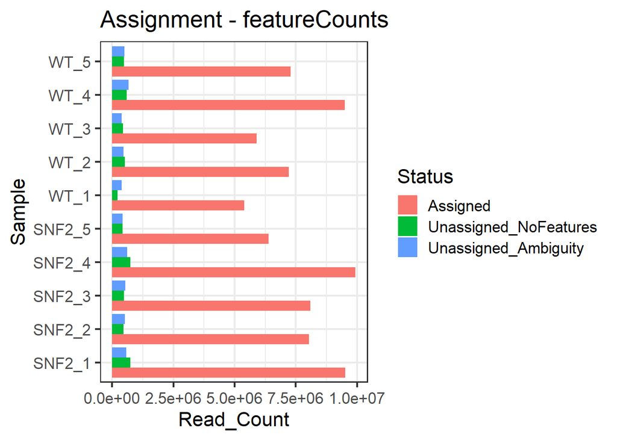

```r
#names(readcounts) <- NULL
dataf <- t(readcounts)
data_new <- dataf                        # Duplicate data frame
colnames(data_new) <- dataf[1, ]          # Convert first row to header
data_new = data_new[-1,]
data_new <- data_new[,c("Assigned", "Unassigned_NoFeatures", "Unassigned_Ambiguity")]

Sample <- c("SNF2_1", "SNF2_2", "SNF2_3", "SNF2_4","SNF2_5","WT_1","WT_2","WT_3","WT_4","WT_5") #Creating list of samples
data=data.frame(cbind(Sample, data_new))   # combine them into a data frame


# melt the data frame for plotting
data.m <- melt(data, id.vars='Sample')
data.m$value <- as.numeric(data.m$value)
names(data.m)[2] <- 'Status'
names(data.m)[3] <- 'Read_Count'

# plotting
ggplot(data.m, aes(Sample, Read_Count)) +
  geom_bar(aes(fill = Status), position = "dodge", stat="identity") +
  coord_flip() +
             ggtitle('Assignment - featureCounts')
```

I ran exactly the same code for featureCounts from class, plot attached below

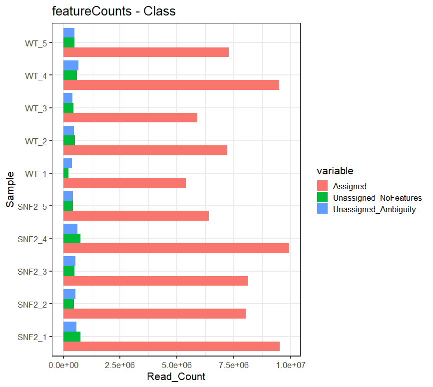

## Part 3

1.Some kind of normalization may be needed because the overall number of reads is greater for SNF2 than WT

## Part 4

I used awk to print the third column of the human annotation file that I’m using for my project. The third column contains the loci. I used sort and uniq to sort the loci and count the unique occurences of each.

```
awk '{print $3}' /athena/angsd/scratch/adg4001/reference/gencode.v39.annotation.gtf | sort | uniq -c
```

```
      4
      1 annotation
 839845 CDS
1552754 exon
  61533 gene
    119 Selenocysteine
  94201 start_codon
  87665 stop_codon
 244939 transcript
 359946 UTR
```